# Note-Machine learning experiment

Weiquan Luo

2021-08-17

# Summary

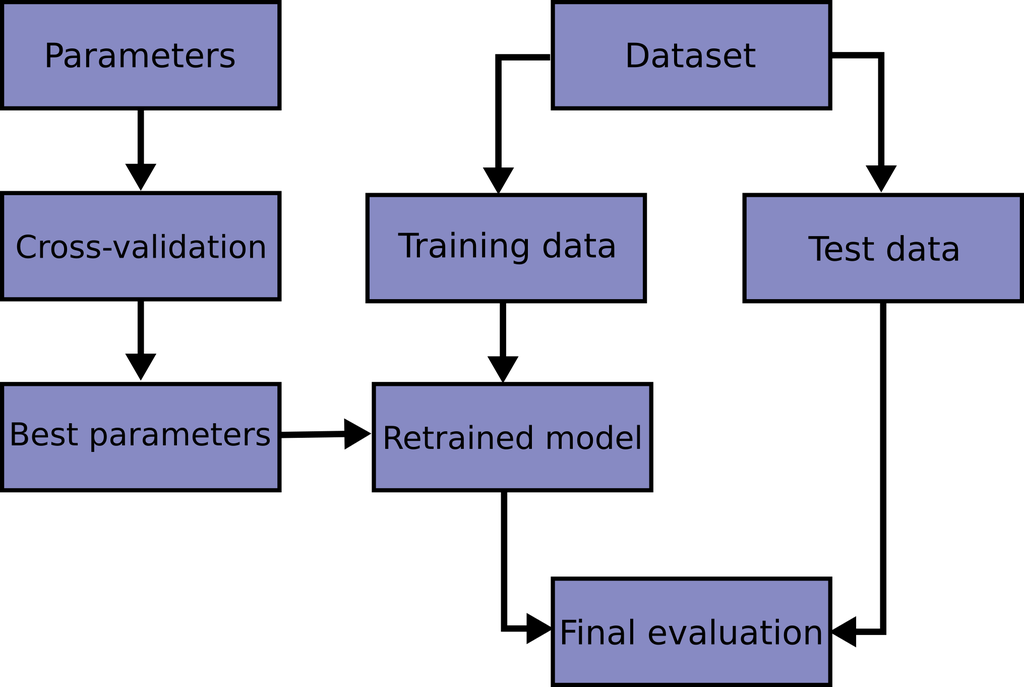

## Machine learning experiment

What Machine learning experiment usualy do?

- search hyper-parameter of a model
- validate/compare performance and generliazation between models (overfit/underfit)

How to conduct a Machine learning experiment:

- making comparision using **cross validatiion**, or CV.

How to make fair comparison among models?

- use same data to sample for validation set

What tool-kit is avaliable?

- Scikit-Learn library provides the two main functionalities to do Machine learning experiment as the following:

| method | composition | focus |
| --- | --- | --- |
| Hyper-parameter optimizers | a warper of estimator, data splitter, parameter grid | search the best set of hyper-parameters of a model |
| Model validator | a warper of estimator and data splitter | validate the models |

## Data streaming pipeline

A pipeline can wrap multiple functionalities including data transformation (scaler, dimentionality reduction) and an estimator to be a single class. It helps to conduct CV on the same data transformation and the same estimator for a fair comparison. Reference: [管道：链式评估器](https://sklearn.apachecn.org/docs/master/31.html)

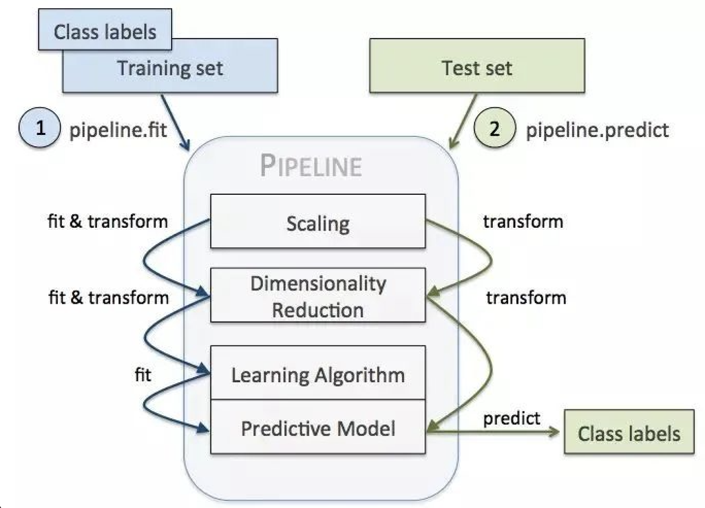

```python
import numpy as np
import matplotlib.pyplot as plt
import pandas as pd
from sklearn import datasets
digits = datasets.load_digits()
X_digits = digits.data
y_digits = digits.target
```

```python
from sklearn.decomposition import PCA
from sklearn.linear_model import SGDClassifier
from sklearn.pipeline import Pipeline
from sklearn.model_selection import GridSearchCV

# scaling
# dimentionality reduction
pca = PCA()
# Learnign algorithm
logistic = SGDClassifier(loss='log', penalty='l2', early_stopping=True,
                         max_iter=10000, tol=1e-5, random_state=0)
# pipeline
pipe = Pipeline(steps=[('pca', pca), ('logistic', logistic)])

print(pipe)
```

```
Pipeline(steps=[('pca', PCA()),
                ('logistic',
                 SGDClassifier(early_stopping=True, loss='log', max_iter=10000,
                               random_state=0, tol=1e-05))])
```

# ML Experiment

## Estimator: fit data

[figure not shown]

source: https://scikit-learn.org/stable/tutorial/machine_learning_map/index.html

## Hyper-parameter optimizers: select Hyper-parameter

`optimizer().fit()`:

- `X,y`: data
- `param_grid`: parameter grid
- `estimator`: class with fit function
- `scoring`: evaluation metric
- `cv`: Splitter (default 5-fold cross validation)

| Hyper-parameter optimizers | description |
| --- | --- |
| model_selection.GridSearchCV() | Exhaustive search over specified parameter values for an estimator. |
| model_selection.HalvingGridSearchCV() | Search over specified parameter values with successive halving. |
| model_selection.ParameterGrid() | Grid of parameters with a discrete number of values for each. |
| model_selection.ParameterSampler() | Generator on parameters sampled from given distributions. |
| model_selection.RandomizedSearchCV() | Randomized search on hyper parameters. |
| model_selection.HalvingRandomSearchCV() | Randomized search on hyper parameters. |

```python
%time
# Parameters of pipelines can be set using ‘__’ separated parameter names:
param_grid = {
    'pca__n_components': [5, 20, 30, 40, 50, 64],
    'logistic__alpha': np.logspace(-4, 4, 5),
}
cv=5
search = GridSearchCV(pipe, param_grid, iid=False, cv=cv, scoring='recall_macro', n_jobs=cv)
search.fit(X_digits, y_digits)

print("Best parameter (CV score=%0.3f):" % search.best_score_)
print(search.best_params_)
```

```
CPU times: user 2 µs, sys: 1 µs, total: 3 µs
Wall time: 5.01 µs
Best parameter (CV score=0.919):
{'logistic__alpha': 0.01, 'pca__n_components': 50}
```

```python
d = {'mean_test_score': search.cv_results_.get('mean_test_score'),
     'std_test_score': search.cv_results_.get('std_test_score'),
     'rank_test_score': search.cv_results_.get('rank_test_score')}
pd.DataFrame(data= search.cv_results_.get('params')).join(pd.DataFrame(data= d))
```

|  | logistic__alpha | pca__n_components | mean_test_score | std_test_score | rank_test_score |
| --- | --- | --- | --- | --- | --- |
| 0 | 0.0001 | 5 | 0.716044 | 0.052309 | 23 |
| 1 | 0.0001 | 20 | 0.887411 | 0.035888 | 15 |
| 2 | 0.0001 | 30 | 0.903600 | 0.044263 | 9 |
| 3 | 0.0001 | 40 | 0.895183 | 0.039510 | 11 |
| 4 | 0.0001 | 50 | 0.891895 | 0.035644 | 14 |
| 5 | 0.0001 | 64 | 0.894120 | 0.043411 | 12 |
| 6 | 0.0100 | 5 | 0.768088 | 0.031506 | 16 |
| 7 | 0.0100 | 20 | 0.903073 | 0.033513 | 10 |
| 8 | 0.0100 | 30 | 0.908520 | 0.026920 | 4 |
| 9 | 0.0100 | 40 | 0.913647 | 0.027858 | 3 |
| 10 | 0.0100 | 50 | 0.919154 | 0.023918 | 1 |
| 11 | 0.0100 | 64 | 0.918032 | 0.025162 | 2 |
| 12 | 1.0000 | 5 | 0.753747 | 0.037280 | 22 |
| 13 | 1.0000 | 20 | 0.892815 | 0.035741 | 13 |
| 14 | 1.0000 | 30 | 0.903896 | 0.037860 | 8 |
| 15 | 1.0000 | 40 | 0.906120 | 0.035376 | 5 |
| 16 | 1.0000 | 50 | 0.906104 | 0.036751 | 6 |
| 17 | 1.0000 | 64 | 0.906104 | 0.036751 | 6 |
| 18 | 100.0000 | 5 | 0.627318 | 0.109118 | 24 |
| 19 | 100.0000 | 20 | 0.764470 | 0.080391 | 21 |
| 20 | 100.0000 | 30 | 0.766754 | 0.080410 | 17 |
| 21 | 100.0000 | 40 | 0.766199 | 0.080017 | 18 |
| 22 | 100.0000 | 50 | 0.765643 | 0.080739 | 19 |
| 23 | 100.0000 | 64 | 0.765643 | 0.080739 | 19 |
| 24 | 10000.0000 | 5 | 0.355885 | 0.314470 | 30 |
| 25 | 10000.0000 | 20 | 0.390485 | 0.356177 | 29 |
| 26 | 10000.0000 | 30 | 0.391597 | 0.357540 | 28 |
| 27 | 10000.0000 | 40 | 0.392168 | 0.358197 | 25 |
| 28 | 10000.0000 | 50 | 0.392168 | 0.358197 | 25 |
| 29 | 10000.0000 | 64 | 0.392168 | 0.358197 | 25 |

## Model validator: check model

`validator()`:

- `X,y`: data
- `estimator`: class with fit function
- `scoring`: evaluation metric
- `cv`: Splitter (default 5-fold cross validation)

| Model validator | validating on |
| --- | --- |
| `sklearn.model_selection.cross_val_score()` | single score |
| `sklearn.model_selection.cross_validate()` | by score |
| `sklearn.model_selection.validation_curve()` | hyper-parameter by score |
| `sklearn.model_selection.learning_curve()` | trained sample by score |

```python
%time
from sklearn.model_selection import cross_validate
from sklearn.metrics import recall_score
scoring = ['precision_macro', 'recall_macro']
cv=5
scores = cross_validate(pipe, X_digits, y_digits, scoring=scoring, cv=cv, return_estimator=True, n_jobs=cv)
```

```
CPU times: user 13 µs, sys: 34 µs, total: 47 µs
Wall time: 7.15 µs
```

```python
[print(x,":",
       np.mean(scores.get('test_'+ x)).round(4),
       '+/-',np.std(scores.get('test_'+ x)).round(4))
 for x in scoring]
```

```
precision_macro : 0.901 +/- 0.039
recall_macro : 0.8941 +/- 0.0434
```

```
[None, None]
```

# Cross-validation API

## Splitter Classes

- train_test_split : divide data set into training set and test set
- kfold: divide data set into prespecified number of folds
- ShuffleSplit: randomly sample the entire dataset, with prespecified number of test_size and train_size

Two categories of the Sampling:

- Stratified Sampling: elements within each stratum(class) are sampled, aims to increase precision to reduce error
- Cluster(group) Sampling: only selected clusters(group) are sampled, aims to reduce cost and increase the efficiency of sampling

One categories TimeSeries data

- TimeSeriesSplit

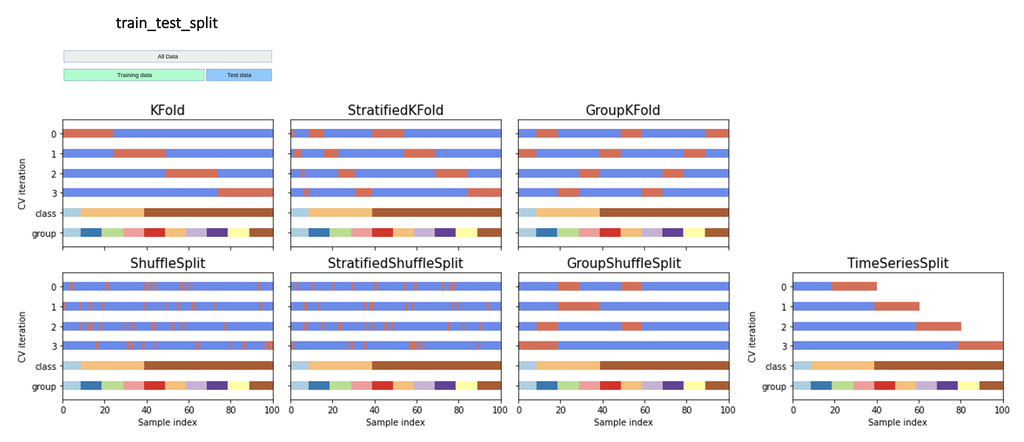

| Less-frequently-used Splitter Classes | Description |
| --- | --- |
| model_selection.LeaveOneGroupOut() | Leave One Group Out cross-validator |
| model_selection.LeavePGroupsOut() | Leave P Group(s) Out cross-validator |
| model_selection.LeaveOneOut() | Leave-One-Out cross-validator |
| model_selection.LeavePOut() | Leave-P-Out cross-validator |
| model_selection.PredefinedSplit() | Predefined split cross-validator |
| model_selection.RepeatedKFold() | Repeated K-Fold cross validator. |
| model_selection.RepeatedStratifiedKFold() | Repeated Stratified K-Fold cross validator. |

## Model specific cross-validation API

| method | description |
| --- | --- |
| `linear_model.ElasticNetCV([l1_ratio, eps, …])` | Elastic Net model with iterative fitting along a regularization path |
| `linear_model.LarsCV([fit_intercept, …])` | Cross-validated Least Angle Regression model |
| `linear_model.LassoCV([eps, n_alphas, …])` | Lasso linear model with iterative fitting along a regularization path |
| `linear_model.LassoLarsCV([fit_intercept, …])` | Cross-validated Lasso, using the LARS algorithm |
| `linear_model.LogisticRegressionCV([Cs, …])` | Logistic Regression CV (aka logit, MaxEnt) classifier. |
| `linear_model.MultiTaskElasticNetCV([…])` | Multi-task L1/L2 ElasticNet with built-in cross-validation. |
| `linear_model.MultiTaskLassoCV([eps, …])` | Multi-task L1/L2 Lasso with built-in cross-validation. |
| `linear_model.OrthogonalMatchingPursuitCV([…])` | Cross-validated Orthogonal Matching Pursuit model (OMP) |
| `linear_model.RidgeCV([alphas, …])` | Ridge regression with built-in cross-validation. |
| `linear_model.RidgeClassifierCV([alphas, …])` | Ridge classifier with built-in cross-validation. |

# Score API

## Classification score

| Scoring | Function | Comment |
| --- | --- | --- |
| ‘accuracy’ | [`metrics.accuracy_score`](https://scikit-learn.org/stable/modules/generated/sklearn.metrics.accuracy_score.html#sklearn.metrics.accuracy_score) |  |
| ‘balanced_accuracy’ | [`metrics.balanced_accuracy_score`](https://scikit-learn.org/stable/modules/generated/sklearn.metrics.balanced_accuracy_score.html#sklearn.metrics.balanced_accuracy_score) |  |
| ‘top_k_accuracy’ | [`metrics.top_k_accuracy_score`](https://scikit-learn.org/stable/modules/generated/sklearn.metrics.top_k_accuracy_score.html#sklearn.metrics.top_k_accuracy_score) |  |
| ‘average_precision’ | [`metrics.average_precision_score`](https://scikit-learn.org/stable/modules/generated/sklearn.metrics.average_precision_score.html#sklearn.metrics.average_precision_score) |  |
| ‘neg_brier_score’ | [`metrics.brier_score_loss`](https://scikit-learn.org/stable/modules/generated/sklearn.metrics.brier_score_loss.html#sklearn.metrics.brier_score_loss) |  |
| ‘f1’ | [`metrics.f1_score`](https://scikit-learn.org/stable/modules/generated/sklearn.metrics.f1_score.html#sklearn.metrics.f1_score) | for binary targets |
| ‘f1_micro’ | [`metrics.f1_score`](https://scikit-learn.org/stable/modules/generated/sklearn.metrics.f1_score.html#sklearn.metrics.f1_score) | micro-averaged |
| ‘f1_macro’ | [`metrics.f1_score`](https://scikit-learn.org/stable/modules/generated/sklearn.metrics.f1_score.html#sklearn.metrics.f1_score) | macro-averaged |
| ‘f1_weighted’ | [`metrics.f1_score`](https://scikit-learn.org/stable/modules/generated/sklearn.metrics.f1_score.html#sklearn.metrics.f1_score) | weighted average |
| ‘f1_samples’ | [`metrics.f1_score`](https://scikit-learn.org/stable/modules/generated/sklearn.metrics.f1_score.html#sklearn.metrics.f1_score) | by multilabel sample |
| ‘neg_log_loss’ | [`metrics.log_loss`](https://scikit-learn.org/stable/modules/generated/sklearn.metrics.log_loss.html#sklearn.metrics.log_loss) | requires `predict_proba` support |
| ‘precision’ etc. | [`metrics.precision_score`](https://scikit-learn.org/stable/modules/generated/sklearn.metrics.precision_score.html#sklearn.metrics.precision_score) | suffixes apply as with ‘f1’ |
| ‘recall’ etc. | [`metrics.recall_score`](https://scikit-learn.org/stable/modules/generated/sklearn.metrics.recall_score.html#sklearn.metrics.recall_score) | suffixes apply as with ‘f1’ |
| ‘jaccard’ etc. | [`metrics.jaccard_score`](https://scikit-learn.org/stable/modules/generated/sklearn.metrics.jaccard_score.html#sklearn.metrics.jaccard_score) | suffixes apply as with ‘f1’ |
| ‘roc_auc’ | [`metrics.roc_auc_score`](https://scikit-learn.org/stable/modules/generated/sklearn.metrics.roc_auc_score.html#sklearn.metrics.roc_auc_score) |  |
| ‘roc_auc_ovr’ | [`metrics.roc_auc_score`](https://scikit-learn.org/stable/modules/generated/sklearn.metrics.roc_auc_score.html#sklearn.metrics.roc_auc_score) |  |
| ‘roc_auc_ovo’ | [`metrics.roc_auc_score`](https://scikit-learn.org/stable/modules/generated/sklearn.metrics.roc_auc_score.html#sklearn.metrics.roc_auc_score) |  |
| ‘roc_auc_ovr_weighted’ | [`metrics.roc_auc_score`](https://scikit-learn.org/stable/modules/generated/sklearn.metrics.roc_auc_score.html#sklearn.metrics.roc_auc_score) |  |
| ‘roc_auc_ovo_weighted’ | [`metrics.roc_auc_score`](https://scikit-learn.org/stable/modules/generated/sklearn.metrics.roc_auc_score.html#sklearn.metrics.roc_auc_score) |  |

## Regression score

| Scoring | Function | Comment |
| --- | --- | --- |
| ‘explained_variance’ | [`metrics.explained_variance_score`](https://scikit-learn.org/stable/modules/generated/sklearn.metrics.explained_variance_score.html#sklearn.metrics.explained_variance_score) |  |
| ‘max_error’ | [`metrics.max_error`](https://scikit-learn.org/stable/modules/generated/sklearn.metrics.max_error.html#sklearn.metrics.max_error) |  |
| ‘neg_mean_absolute_error’ | [`metrics.mean_absolute_error`](https://scikit-learn.org/stable/modules/generated/sklearn.metrics.mean_absolute_error.html#sklearn.metrics.mean_absolute_error) |  |
| ‘neg_mean_squared_error’ | [`metrics.mean_squared_error`](https://scikit-learn.org/stable/modules/generated/sklearn.metrics.mean_squared_error.html#sklearn.metrics.mean_squared_error) |  |
| ‘neg_root_mean_squared_error’ | [`metrics.mean_squared_error`](https://scikit-learn.org/stable/modules/generated/sklearn.metrics.mean_squared_error.html#sklearn.metrics.mean_squared_error) |  |
| ‘neg_mean_squared_log_error’ | [`metrics.mean_squared_log_error`](https://scikit-learn.org/stable/modules/generated/sklearn.metrics.mean_squared_log_error.html#sklearn.metrics.mean_squared_log_error) |  |
| ‘neg_median_absolute_error’ | [`metrics.median_absolute_error`](https://scikit-learn.org/stable/modules/generated/sklearn.metrics.median_absolute_error.html#sklearn.metrics.median_absolute_error) |  |
| ‘r2’ | [`metrics.r2_score`](https://scikit-learn.org/stable/modules/generated/sklearn.metrics.r2_score.html#sklearn.metrics.r2_score) |  |
| ‘neg_mean_poisson_deviance’ | [`metrics.mean_poisson_deviance`](https://scikit-learn.org/stable/modules/generated/sklearn.metrics.mean_poisson_deviance.html#sklearn.metrics.mean_poisson_deviance) |  |
| ‘neg_mean_gamma_deviance’ | [`metrics.mean_gamma_deviance`](https://scikit-learn.org/stable/modules/generated/sklearn.metrics.mean_gamma_deviance.html#sklearn.metrics.mean_gamma_deviance) |  |
| ‘neg_mean_absolute_percentage_error’ | [`metrics.mean_absolute_percentage_error`](https://scikit-learn.org/stable/modules/generated/sklearn.metrics.mean_absolute_percentage_error.html#sklearn.metrics.mean_absolute_percentage_error) |  |

## Clustering score

| Scoring | Function | Comment |
| --- | --- | --- |
| ‘adjusted_mutual_info_score’ | [`metrics.adjusted_mutual_info_score`](https://scikit-learn.org/stable/modules/generated/sklearn.metrics.adjusted_mutual_info_score.html#sklearn.metrics.adjusted_mutual_info_score) |  |
| ‘adjusted_rand_score’ | [`metrics.adjusted_rand_score`](https://scikit-learn.org/stable/modules/generated/sklearn.metrics.adjusted_rand_score.html#sklearn.metrics.adjusted_rand_score) |  |
| ‘completeness_score’ | [`metrics.completeness_score`](https://scikit-learn.org/stable/modules/generated/sklearn.metrics.completeness_score.html#sklearn.metrics.completeness_score) |  |
| ‘fowlkes_mallows_score’ | [`metrics.fowlkes_mallows_score`](https://scikit-learn.org/stable/modules/generated/sklearn.metrics.fowlkes_mallows_score.html#sklearn.metrics.fowlkes_mallows_score) |  |
| ‘homogeneity_score’ | [`metrics.homogeneity_score`](https://scikit-learn.org/stable/modules/generated/sklearn.metrics.homogeneity_score.html#sklearn.metrics.homogeneity_score) |  |
| ‘mutual_info_score’ | [`metrics.mutual_info_score`](https://scikit-learn.org/stable/modules/generated/sklearn.metrics.mutual_info_score.html#sklearn.metrics.mutual_info_score) |  |
| ‘normalized_mutual_info_score’ | [`metrics.normalized_mutual_info_score`](https://scikit-learn.org/stable/modules/generated/sklearn.metrics.normalized_mutual_info_score.html#sklearn.metrics.normalized_mutual_info_score) |  |
| ‘rand_score’ | [`metrics.rand_score`](https://scikit-learn.org/stable/modules/generated/sklearn.metrics.rand_score.html#sklearn.metrics.rand_score) |  |
| ‘v_measure_score’ | [`metrics.v_measure_score`](https://scikit-learn.org/stable/modules/generated/sklearn.metrics.v_measure_score.html#sklearn.metrics.v_measure_score) |  |